# Exploring the BRFSS data

Author: Bruno Hunkeler  
Date: 24.05.2016

## Behavioral Risk Factor Surveillance System

The Behavioral Risk Factor Surveillance System (BRFSS) is a collaborative project between all of the states in the United States (US) and participating US territories and the Centers for Disease Control and Prevention (CDC). The BRFSS is administered and supported by CDC’s Population Health Surveillance Branch, under the Division of Population Health at the National Center for Chronic Disease Prevention and Health Promotion. **BRFSS is an ongoing surveillance system designed to measure behavioral risk factors for the non-institutionalized adult population (18 years of age and older) residing in the US.**

The BRFSS objective is to collect uniform, state-specific data on preventive health practices and risk behaviors that are linked to chronic diseases, injuries, and preventable infectious diseases that affect the adult population. Factors assessed by the BRFSS in 2013 include tobacco use, HIV/AIDS knowledge and prevention, exercise, immunization, health status, healthy days — health-related quality of life, health care access, inadequate sleep, hypertension awareness, cholesterol awareness, chronic health conditions, alcohol consumption, fruits and vegetables consumption, arthritis burden, and seatbelt use.

### Data collection

Since 2011, BRFSS conducts both landline telephone- and cellular telephone-based surveys. In conducting the BRFSS landline telephone survey, interviewers collect data from a randomly selected adult in a household. In conducting the cellular telephone version of the BRFSS questionnaire, interviewers collect data from an adult who participates by using a cellular telephone and resides in a private residence or college housing.

BRFSS field operations are managed by state health departments that follow protocols adopted by the states with technical assistance provided by CDC. State health departments collaborate during survey development, and conduct the interviews themselves or by using contractors. The data are transmitted to the CDC for editing, processing, weighting, and analysis. An edited and weighted data file is provided to each participating health department for each year of data collection, and summary reports of state-specific data are prepared by the CDC.

The data and further information were obtained from the following sources:

Dataset: Behavioral Risk Factor Surveillance System Data [53MB]

General Information: [2013 Survey Data Information](http://www.cdc.gov/brfss/annual_data/annual_2013.html)

- [2013 BRFSS Overview](http://www.cdc.gov/brfss/annual_data/2013/pdf/overview_2013.pdf) [PDF - 84 KB]  
  Provides information on the background, design, data collection and processing, statistical, and  
  analytical issues for the combined landline and cell phone data set.
- [2013 BRFSS Codebook](http://www.cdc.gov/brfss/annual_data/2013/pdf/codebook13_llcp.pdf) [PDF - 2.7 MB]  
  Codebook for the file showing variable name, location, and frequency of values for all reporting  
  areas combined for the combined landline and cell phone data set.
- [Calculated Variables in Data Files](http://www.cdc.gov/brfss/annual_data/2013/pdf/2013_calculated_variables_version15.pdf) [PDF - 421 KB]
- [Comparability of Data](http://www.cdc.gov/brfss/annual_data/2013/pdf/compare_2013.pdf) [PDF - 96 KB]  
  Comparability of data across reporting areas for the combined landline and cell phone data set.  
  The BRFSS 2012 data is not directly comparable to years of BRFSS data before 2011 because of the  
  changes in weighting methodology and the addition of the cell phone sampling frame.
- [2013 Weighting Formula](http://www.cdc.gov/brfss/annual_data/2013/pdf/weighting_data.pdf) [PDF - 98 KB]
- [Summary Matrix of Calculated Variables (CV) in the 2013 Data File](http://www.cdc.gov/brfss/annual_data/2013/summary_matrix_2013_version5.html)

### Generalizability / Causality

#### Target Population

Over time, the number of states participating in the survey increased; by 2001, 50 states were participating. Today all States in the US are part of the survey. BRFSS conducts both landline telephone- and cellular telephone-based surveys. In conducting the BRFSS landline telephone survey, interviewers collect data from a randomly selected adult in a household for the non-institutionalized adult population (18 years of age and older) residing in the US.

Overall, an estimated 97.5% of US households had telephone service in 2012. Telephone coverage varies across states with a range of 95.3% in New Mexico to 98.6% in Connecticut. The data collection is based on a **stratified sampling** strategy.  
The population is divided into groups (States) called strata. Then a **random sampling** (telephone), has been employed within  
each stratum.

#### Causality

The study, by gathering survey data, has the character of an observational study. Taking causal conclusions is almost never  
recommended based on observational data. In observational studies as this one it is generally only sufficient to show  
associations.Even if random sampling, as mentionaed above, has been applied the questionnaire leaves a lot of open questions.  
There are environmetal, stress, social etc. aspects to be considered if we want to consider the health of a person.

## **Setup**

### **Load packages**

```r
library('ggplot2')    # library to create plots
library('plyr')       # data manipulation
library('dplyr')      # data manipulation
library('gridExtra')  # supports the layout functionality with ggplot
library('ggmap')      # visualize maps
library('knitr')      # required to apply knitr options
library('gtable')     # used to overlay plots in ggplot
library('grid')       # used to overlay plots in ggplot

# apply general knitr options
knitr::opts_chunk$set(comment=NA, fig.align='center')
```

### **Load data**

Initial load of the dataset. There is also a definition of the population living in the US in 2013.

```r
# ============================================================================================================
# Download and extract Data and load file
# ============================================================================================================

# load the data set
load(file = 'Data/brfss2013.RData')
```

### **Part 1: Data**

The initial part of the project is get to know your data. I mainly worked with two documents - [Calculated Variables in Data Files](http://www.cdc.gov/brfss/annual_data/2013/pdf/2013_calculated_variables_version15.pdf) and [2013 BRFSS Codebook](http://www.cdc.gov/brfss/annual_data/2013/pdf/codebook13_llcp.pdf). The analysis of the data requires various steps to figure out what information is useful or can be discarded. I’ll focus on one example to transport the idea of how I analyzed the data. The plots won’t be nice and tidy since those are only used for a quick and dirty analysis.

```r
# evaluate the size of the dataset
dim(brfss2013)
```

```
[1] 491775    330
```

The output for the summary- and str() - function has been hidden since the output would be quiet exhaustive (verbose) by having 330 variables.

```r
# verify types and summary of each variable
str(brfss2013)
summary(brfss2013)
```

I reduced the dataset for convenience reasons. I went through the dataset to separate the wheat from the chaff. I verified the number of ‘NA’ in each variable. Check if it is required to apply an algorithm to fill in the missing data or if I just can delete the incomplete rows. I also verified IRQ’s etc. Visualization has been used to verify the distribution and to find potential outliners. I used histogramms, boxplots and Q-Q Plot’s to visually analyse the data. The steps taken, gave me a quite clear picture of the dataset at hand.

```r
# Create a subset of the analysed data, which might be interesting for the rresearch questions
Col <- c('X_state', 'X_bmi5', 'X_bmi5cat', 'genhlth', 'hlthpln1', 'exerany2', 'X_frtlt1', 'X_veglt1', 'X_pacat1', 'exract11', 'X_age80', 'weight2', 'height3', 'income2', 'educa')
data.analysis <- brfss2013[, Col]

str(data.analysis)
```

```
'data.frame':   491775 obs. of  15 variables:
 $ X_state  : Factor w/ 55 levels "0","Alabama",..: 2 2 2 2 2 2 2 2 2 2 ...
 $ X_bmi5   : int  3916 1822 2746 2197 3594 3986 2070 NA 3017 2829 ...
 $ X_bmi5cat: Factor w/ 4 levels "Underweight",..: 4 1 3 2 4 4 2 NA 4 3 ...
 $ genhlth  : Factor w/ 5 levels "Excellent","Very good",..: 4 3 3 2 3 2 4 3 1 3 ...
 $ hlthpln1 : Factor w/ 2 levels "Yes","No": 1 1 1 1 1 1 1 1 1 1 ...
 $ exerany2 : Factor w/ 2 levels "Yes","No": 2 1 2 1 2 1 1 1 1 1 ...
 $ X_frtlt1 : Factor w/ 2 levels "Consumed fruit one or more times per day",..: 1 2 2 2 2 1 1 2 1 2 ...
 $ X_veglt1 : Factor w/ 2 levels "Consumed vegetables one or more times per day",..: 2 1 1 1 1 1 1 1 1 1 ...
 $ X_pacat1 : Factor w/ 4 levels "Highly active",..: 4 3 4 3 4 3 2 3 2 2 ...
 $ exract11 : Factor w/ 75 levels "Active Gaming Devices (Wii Fit, Dance, Dance revolution)",..: NA 64 NA 64 NA 6 64 64 7 64 ...
 $ X_age80  : int  60 50 55 64 66 49 39 60 50 68 ...
 $ weight2  : Factor w/ 570 levels "",".b","100",..: 154 30 63 31 169 128 9 1 139 73 ...
 $ height3  : int  507 510 504 504 600 503 500 505 602 505 ...
 $ income2  : Factor w/ 8 levels "Less than $10,000",..: 7 8 8 7 6 8 NA 6 8 4 ...
 $ educa    : Factor w/ 6 levels "Never attended school or only kindergarten",..: 6 5 6 4 6 6 4 5 6 4 ...
```

```r
# slightly right skewed
summary(data.analysis$X_bmi5)
```

```
   Min. 1st Qu.  Median    Mean 3rd Qu.    Max.    NA's
      1    2367    2663    2782    3081    9769   26727
```

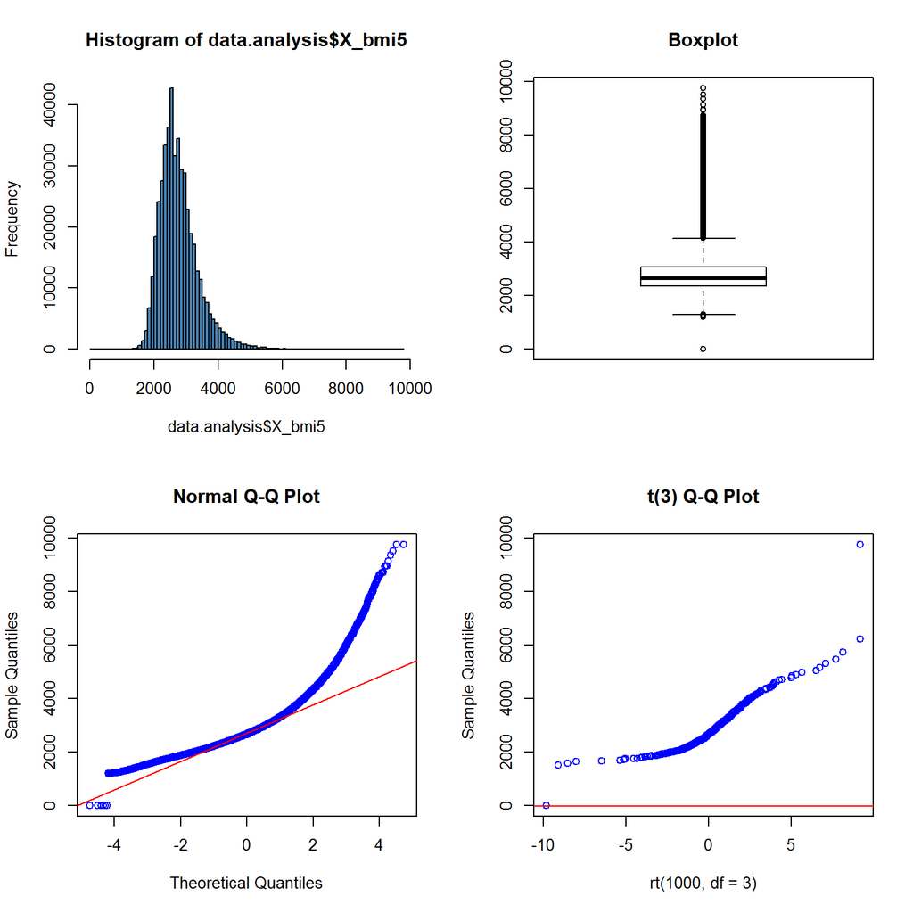

```r
# create a 2 by 2 plot
par(mfrow = c(2, 2))

# show the histogram and boxplot to verify the distribution
hist(data.analysis$X_bmi5, breaks = 100, col = 'steelblue')
boxplot(data.analysis$X_bmi5, main = "Boxplot")

# normal fit
qqnorm(data.analysis$X_bmi5, col = 'blue');
qqline(data.analysis$X_bmi5, col = 'red')

# t(3Df) fit
qqplot(rt(1000, df = 3), data.analysis$X_bmi5, main = "t(3) Q-Q Plot",
   ylab = "Sample Quantiles", col = 'blue')
abline(0, 1, col = 'red')
```

```r
# calculate mean value
mean(data.analysis$X_bmi5, na.rm = TRUE)
```

```
[1] 2782.448
```

```r
# calculate median values
median(data.analysis$X_bmi5, na.rm = TRUE)
```

```
[1] 2663
```

After analysing the data I created subsets of the initial dataset. Each research questing has it’s own subset. One exception to every rule. Research question 3 has been separated into 3 different datasets right from the start.

```r
# ============================================================================================================
# Create Data subsets for each research question by providing only the required columns
# ============================================================================================================

# Data set for research question 1
Col <- c('X_state', 'X_bmi5', 'X_bmi5cat')
data.rsq1 <- brfss2013[, Col]

# Data set for research question 2
Col <- c('X_state', 'genhlth', 'hlthpln1', 'X_bmi5cat', 'exerany2')
data.rsq2 <- brfss2013[, Col]

# Data set for research question 3
Col <- c('X_bmi5', 'X_age80')
data.rsq3 <- brfss2013[, Col]

# Data set for research question 4
Col <- c('X_bmi5', 'X_frtlt1', 'X_frutsum', 'X_veglt1', 'X_vegesum', 'X_age80')
data.rsq3_a <- brfss2013[, Col]

# Data set for research question 5
Col <- c('pa1min_', 'X_age80')
data.rsq3_b <- brfss2013[, Col]
```

### **Part 2: Research questions**

I’ll focus on a widespread social problem - overweight or obesity.

#### **Research question 1:**

Does the access of health care influence the ‘general health’ of the population and can we infer a relation (association)  
between ‘general health’ the physical exercise a person performs?  
ObamaCare, officially called the Patient Protection and Affordable Care Act (PPACA), reforms the health insurance industry  
and the American health care system as a whole.  
The law contains over a thousand pages of provisions that give Americans more rights and protections and expand access to  
affordable quality health care to tens of millions of uninsured. The health care plan is still relatively new, therefore  
it is interesting to see if, having a health care plan already has an impact on the general health of the population. Health care does usually not only include access to doctors and financial aid. It also informs the population, what might be  
required in respect to better ‘general health’. This includes information about balanced nutrition or physical activities (excercise) etc.

#### **Research question 2:**

To continue the initial question about the US population belonging to which BMI category. I’m interested to find out, which state has the highest obesity rate in the US and what is the distribution troughout the United states in 2013?  
The distribution of the obese population might give an idea if there is a relation (pattern) between rural or municipal areas,  
which than leads to more detailled questions as if there might be relations between obesity and physical activity, nutrition,  
income, health care access or education.

#### **Research question 3:**

Is there a relation between BMI and an ‘age group’ and can we infere a relation (association) between the BMI of age groups and their  
nutrition behavior as well as pysical activity pattern?  
Is it given that a person over the years gains weight, or does an aging person change its behavior in nutrition and pysical activity,  
and therefore is able to lead ab healthier life?

### **Part 3: Exploratory data analysis**

#### **Research question 1:**

The first part of this questions solves the question - what percentage of the us population is associated with which  
bmi category. This is only used to get an general overview, on how we have to classify the situation. ObamaCare, officially  
called the Patient Protection and Affordable Care Act (PPACA), reforms the health insurance industry and the  
American health care system as a whole. The law gives Americans more rights and protections and expands access to  
affordable quality health care to tens of millions of uninsured. The health care plan is still relatively new, therefore  
it is interesting to see if, having a health care plan already has an impact on the general health of the population.  
I first preprocessed the data towards being able to evaluate the percentage of the US population based on BMI category.  
The calculated figures are displayed in the following plot as well as in a table below. The preprocessing step first cleans the data from NA values and then data manipulation to calculate the percentage for each category.

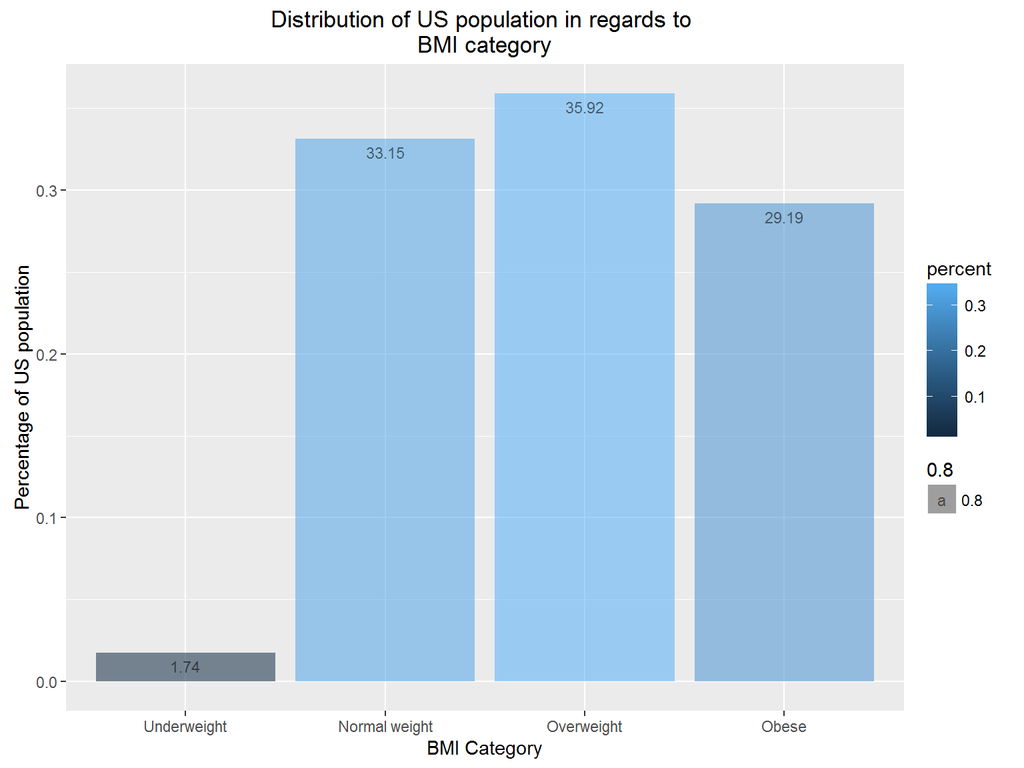

```r
    # ====================================================================================================
    # Data preprocessing
    # ====================================================================================================

    USPopulation2013 <- 315091138

    # remove rows with missing data
    data.rsq2 <- data.rsq2[complete.cases(data.rsq2),]

    # evaluate the percentage of the US population based on bmi Category
    bmi.cat <- plyr::count(data.rsq2, 'X_bmi5cat')
    bmi.cat <- bmi.cat[-5,]
    bmi.cat$percent <- prop.table(bmi.cat$freq)
    bmi.cat$population <- lapply(bmi.cat$percent, function(x) {
        USPopulation2013 * x
    })

    # ====================================================================================================
    # Create Plots
    # ====================================================================================================

    ggplot(bmi.cat, aes(x = factor(X_bmi5cat), y = percent, fill = percent, alpha = 0.8)) +
    geom_bar(stat = 'identity') +
    xlab('BMI Category') + ylab('Percentage of US population') +
    ggtitle('Distribution of US population in regards to \nBMI category') +
    geom_text(aes(label = round(percent * 100, 2)), vjust = 1.6, color = 'black', position = position_dodge(0.9), size = 3)
```

The table indicates that about 2/3 of the US population are overweight or obese. This means that around 200 million people  
fall in one or the other category. Such numbers are alarming since this can cause enormous health- as well as economic cost  
in the future.

| BMI category | Percentage of US population | Number of people in category |
| --- | --- | --- |
| Underweight | 1.74% | 5’497’557 |
| Normal weight | 33.15% | 104’445’574 |
| Overweight | 35.92% | 113’176’902 |
| Obese | 29.19% | 91’971’105 |

The mosaic plots below show on one hand the relation between the general health and the health care access. On the  
other hand the relation between general health and the physical exercise.  
The ‘health care plan’ is still relatively new for lots of the US population , therefore it is interesting to see if, having a  
health care plan already has an impact on the general health of the population. The graphic indicates that there is no explicite  
trend (change) to be found, but if we assume that having a health care plan also sensitizes people with regard to physical exercise  
or nutrition, we see a clear trend that people, performing physical exercise more often tend to lead a healthier life.  
Even if it seems that we might have a causal relation, I wouldn’t go that far, since a lot of other factors might be influencing  
the general health of a person as environmental factors, stress related factors etc.

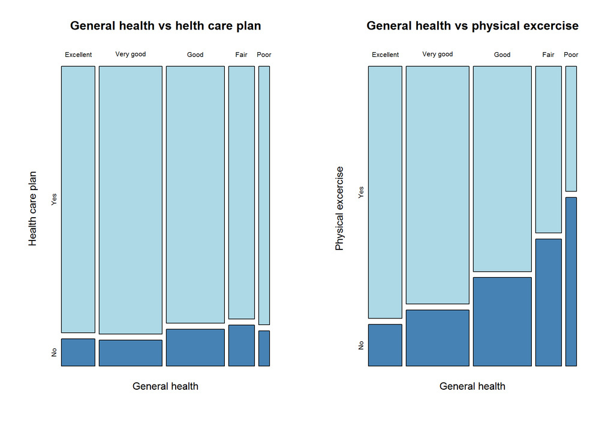

```r
    # ====================================================================================================
    # Create Plots
    # ====================================================================================================

    par(mfrow = c(1, 2))

    # is there a relation between healt care and general condition
    mosaicplot( ~ genhlth + hlthpln1, data = data.rsq2, xlab = 'General health', ylab = 'Health care plan', color = c('lightblue', 'steelblue'),
                main = 'General health vs helth care plan')

    # is there a relation between exercise and general condition
    mosaicplot( ~ genhlth + exerany2, data = data.rsq2, xlab = 'General health', ylab = 'Physical excercise', color = c('lightblue', 'steelblue'),
                main = 'General health vs physical excercise')
```

```r
    # clean up unused variables
    rm(bmi.cat)
    rm(data.rsq2)
    rm(USPopulation2013)
```

#### **Research question 2:**

```r
    # ====================================================================================================
    # Data preprocessing
    # ====================================================================================================

    # remove rows with missing data
    data.rsq1 <- data.rsq1[complete.cases(data.rsq1),]

    # calculate sample size per state
    survey.population.State <- plyr::count(data.rsq1, 'X_state')
    colnames(survey.population.State) <- c('X_state', 'Sample')

    # filter for people being Obese
    # filter.Obese <- data.rsq1 %>% filter(X_bmi5cat == 'Obese')
    filter.Obese <- subset(data.rsq1, data.rsq1$X_bmi5cat == 'Obese')

    # calculate sample size of Obese people per state
    obese.population.State <- plyr::count(filter.Obese, 'X_state')
    colnames(obese.population.State) <- c('X_state', 'Obese')

    # merge data sets and calc percentage
    survey.population.State <- merge(survey.population.State, obese.population.State)
    survey.population.State$Percent <- with(survey.population.State, round(Obese * 100 / Sample, 2))
```

The prepared data is displayed in a ‘heat map’ of the United State, indicating which state has the highest  
obesity rate. This requires to merge the map data with the preprocessed survey data. There is also a plot showing  
the ranking of the top 20 states.

```r
    # ====================================================================================================
    # Data preprocessing
    # ====================================================================================================

    # load map data
    statesMap <- map_data("state")
```

```
 # maps v3.1: updated 'world': all lakes moved to separate new #
 # 'lakes' database. Type '?world' or 'news(package="maps")'.  #
```

```r
    # str(statesMap)

    # merge the obesity with map data
    colnames(survey.population.State) <- c('region', 'sample', 'obese', 'percent')
    survey.population.State$region <- tolower(survey.population.State$region)
    surveyMap <- merge(statesMap, survey.population.State, by = "region")

    str(surveyMap)
```

```
'data.frame':   15537 obs. of  9 variables:
 $ region   : chr  "alabama" "alabama" "alabama" "alabama" ...
 $ long     : num  -87.5 -87.5 -87.5 -87.5 -87.6 ...
 $ lat      : num  30.4 30.4 30.4 30.3 30.3 ...
 $ group    : num  1 1 1 1 1 1 1 1 1 1 ...
 $ order    : int  1 2 3 4 5 6 7 8 9 10 ...
 $ subregion: chr  NA NA NA NA ...
 $ sample   : int  6244 6244 6244 6244 6244 6244 6244 6244 6244 6244 ...
 $ obese    : int  2138 2138 2138 2138 2138 2138 2138 2138 2138 2138 ...
 $ percent  : num  34.2 34.2 34.2 34.2 34.2 ...
```

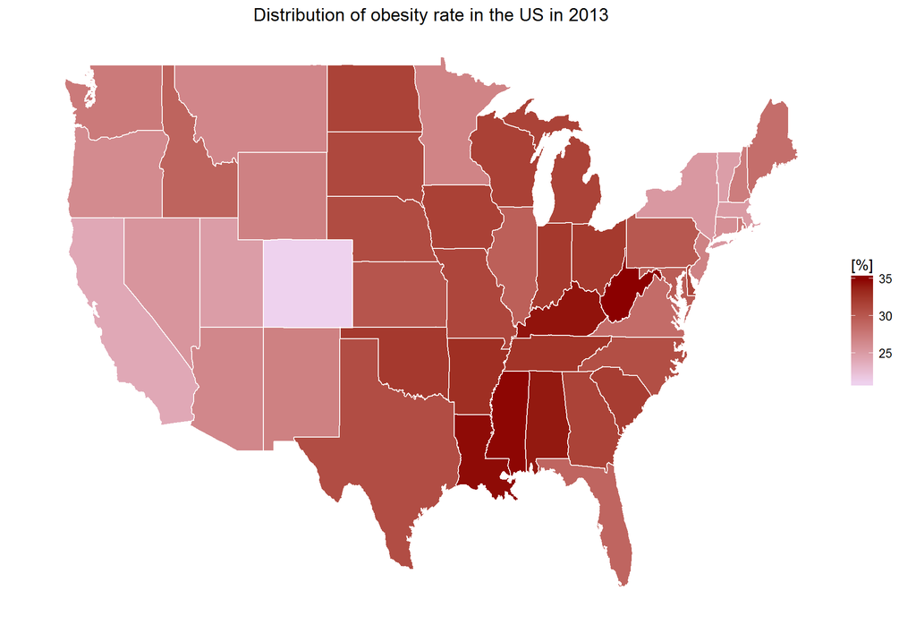

```r
    # ====================================================================================================
    # Create Plots
    # ====================================================================================================

    # plot the US map and assign the heatmap
    ggplot() +
    geom_polygon(data = surveyMap, aes(x = long, y = lat, group = group, fill = percent), colour = "white") +
    scale_fill_continuous(low = "thistle2", high = "darkred", guide = "colorbar") +
    theme_bw() + labs(fill = "[%]", title = "Distribution of obesity rate in the US in 2013", x = "", y = "") +
    scale_y_continuous(breaks = c()) + scale_x_continuous(breaks = c()) + theme(panel.border = element_blank())
```

```r
    # order dataset descending and filter top 20 rows
    survey.population.State.ordered <- survey.population.State[order( - survey.population.State$percent),]
    survey.population.State.ordered$sample <- NULL
    survey.population.State.ordered$obese <- NULL
    survey.population.State.ordered <- filter(survey.population.State.ordered, percent > 1) %>% top_n(20)
```

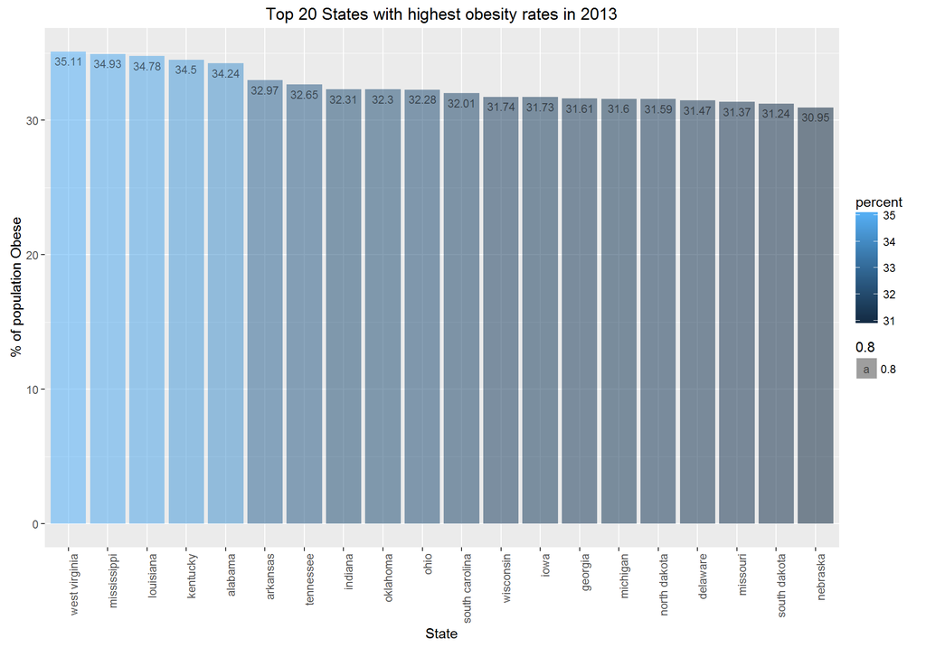

```r
    ggplot(data = survey.population.State.ordered, aes(x = reorder(survey.population.State.ordered$region,
           - survey.population.State.ordered$percent), y = survey.population.State.ordered$percent,
         fill = percent, alpha = 0.8)) +
         geom_bar(stat = "identity") +
         xlab("State") + ylab("% of population Obese") +
         ggtitle("Top 20 States with highest obesity rates in 2013") +
         theme(axis.text.x = element_text(angle = 90, hjust = 1)) +
         geom_text(aes(label = percent), vjust = 1.6, color = "black", position = position_dodge(0.9), size = 3)
```

#### **Research question 3:**

In this part I’ll answer the question, if there is a relation between BMI and an ‘age group’ and can we infere  
a relation (association) between the BMI of age groups and their nutrition behavior as well as pysical activity pattern.  
To answer this question we again have to perform some data preprocessing steps as removing NA values, calculating  
the average value of the BMI for each age goup and put them in relation.  
The fact that the BMI has a steep upwards curve from age 18 up to 40 and than levels out until the age 60, is no real surprise.  
But the fact that after 60 the average BMI drops again, ‘nota bene’ not only slightly, rather in a steep curve is quite suprising  
to me. My hypothesis was that with higher age the BMI levels out on a high rate and stays there for the last quarter of the life time.

```r
    # ====================================================================================================
    # Data preprocessing
    # ====================================================================================================

    # print unique vales
    unique(data.rsq3$X_age80)
```

```
 [1] 60 50 55 64 66 49 39 68 44 57 73 63 65 70 32 46 74 75 43 78 51 67 52
[24] 59 77 61 56 71 58 30 36 69 72 53 45 76 62 34 38 37 26 24 80 29 47 54
[47] 19 42 25 31 33 48 21 40 41 22 18 23 28 79 27 20 35  2 NA  1  0  3
```

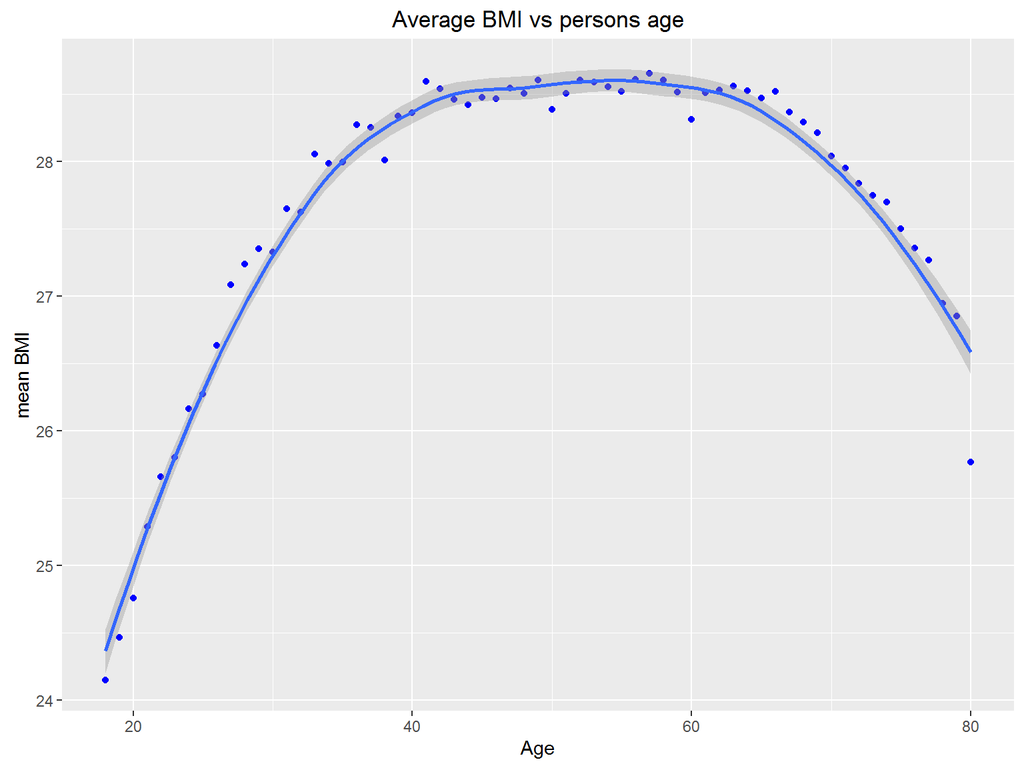

```r
    # remove NA values
    data.rsq3 <- data.rsq3[complete.cases(data.rsq3),]

    # convert BMI to percentage and round value
    data.rsq3$X_bmi5 <- lapply(data.rsq3$X_bmi5, function(x) {
        round(x / 100, 2)
    })

    # flatten list to vector
    data.rsq3$X_bmi5 <- unlist(data.rsq3$X_bmi5, use.names = TRUE)

    mean.bmi <- ddply(data.rsq3, .(X_age80), summarise, mean = mean(X_bmi5))

    # remove age 1 and 2
    mean.bmi <- mean.bmi[-1:-2,]

    # ====================================================================================================
    # Create Plots
    # ====================================================================================================

    ggplot(mean.bmi, aes(x = mean.bmi$X_age80, y = mean)) +
    geom_point(col = 'blue') +
    geom_smooth() +
    ylab('mean BMI') + xlab("Age") +
    ggtitle("Average BMI vs persons age")
```

The following plot show the average BMI per age as well as the average Nutition per age. Can we infere a causal relation between  
the two curves? As mentioned earlier, a causal relation might be implied, but there are lots of other factors who can  
influence such a situation. But we can imply an association of the different factors.

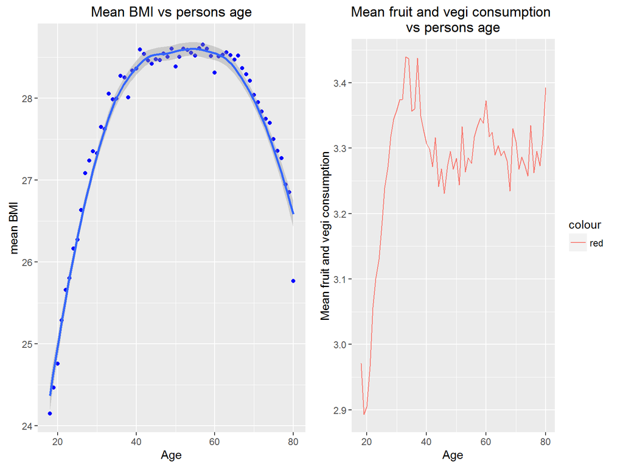

```r
    # ====================================================================================================
    # Data preprocessing
    # ====================================================================================================

    # remove NA values
    data.rsq3_a <- data.rsq3_a[complete.cases(data.rsq3_a),]

    data.rsq3_a <- data.rsq3_a %>% mutate(X_frtlt1 = ifelse(X_frtlt1 %in%
                                                    c("Consumed fruit one or more times per day"), 1, 0))
    data.rsq3_a <- data.rsq3_a %>% mutate(X_veglt1 = ifelse(X_veglt1 %in%
                                                    c("Consumed vegetables one or more times per day"), 1, 0))

    data.rsq3_a$nutrition <- with(data.rsq3_a, round(((X_frutsum + X_vegesum) / 100), 2))

    mean.nutrition <- ddply(data.rsq3_a, .(X_age80), summarise, meanNu = mean(nutrition))

    # remove age 1
    mean.nutrition <- mean.nutrition[-1,]

    # ====================================================================================================
    # Create Plots
    # ====================================================================================================

    mean.p1 <- ggplot(mean.bmi, aes(x = X_age80, y = mean)) +
    geom_point(col = 'blue') +
    geom_smooth() +
    ylab('mean BMI') + xlab("Age") +
    ggtitle("Mean BMI vs persons age")

    mean.nutrition.p1 <- ggplot(mean.nutrition, aes(x = X_age80, y = mean)) +
    ylab('Mean fruit and vegi consumption') + xlab("Age") +
    ggtitle("Mean fruit and vegi consumption \nvs persons age") +
    geom_line(aes(y = mean.nutrition$mean, colour = "red"))

    grid.arrange(mean.p1, mean.nutrition.p1, ncol = 2)
```

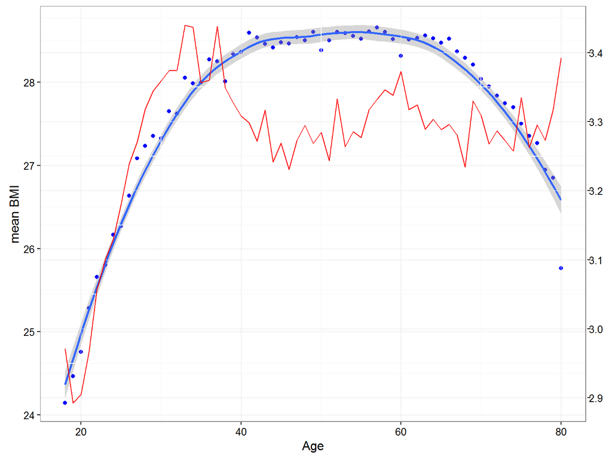

```r
    # ====================================================================================================
    # Create Plots
    # ====================================================================================================

    grid.newpage()

    p1 <- ggplot(mean.bmi, aes(x = X_age80, y = mean)) +
    geom_point(col = 'blue') +
    ylab('mean BMI') + xlab("Age") +
    geom_smooth() + theme_bw()

    p2 <- ggplot(mean.nutrition, aes(x = X_age80, y = mean)) +
    geom_line(aes(y = mean.nutrition$mean), col = "red") +
    ylab('Mean Fruit and Vegi consumtion') +
    theme_bw() %+replace%
    theme(panel.background = element_rect(fill = NA), plot.margin = unit(c(2,2,2,2), 'cm'))

    # this function overlays two idividual plots to better identify a relation
    overlay <- function(p1, p2) {

    # extract gtable
    g1 <- ggplot_gtable(ggplot_build(p1))
    g2 <- ggplot_gtable(ggplot_build(p2))

    # overlap the panel of 2nd plot on that of 1st plot
    pp <- c(subset(g1$layout, name == "panel", se = t:r))
    g <- gtable_add_grob(g1, g2$grobs[[which(g2$layout$name == "panel")]], pp$t,
    pp$l, pp$b, pp$l)

    # axis tweaks
    ia <- which(g2$layout$name == "axis-l")
    ga <- g2$grobs[[ia]]
    ax <- ga$children[[2]]
    ax$widths <- rev(ax$widths)
    ax$grobs <- rev(ax$grobs)
    ax$grobs[[1]]$x <- ax$grobs[[1]]$x - unit(1, "npc") + unit(0.15, "cm")
    g <- gtable_add_cols(g, g2$widths[g2$layout[ia,]$l], length(g$widths) - 1)
    g <- gtable_add_grob(g, ax, pp$t, length(g$widths) - 1, pp$b)

    # draw it
    grid.draw(g)
}

overlay(p1, p2)
```

We consider again the same data displayed previously with the average BMI per age, but this time we will put those data in relation  
to physical exercise. We see again two plots one we have seen before. The other displays the average excercise performed by the  
population of a certain age.

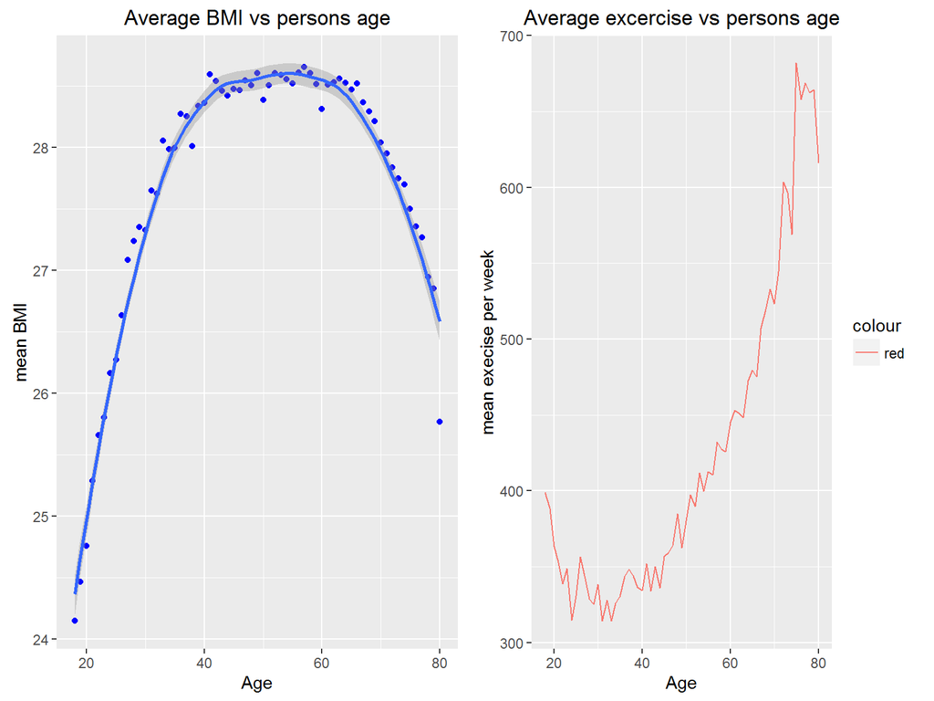

```r
    # remove NA values
    data.rsq3_b <- data.rsq3_b[complete.cases(data.rsq3_b),]

    mean.exercise <- ddply(data.rsq3_b, .(X_age80), summarise, meanEx = mean(pa1min_))

    # remove age 1 and 2
    mean.exercise <- mean.exercise[-1:-2,]

    mean.p1 <- ggplot(mean.bmi, aes(x = X_age80, y = mean)) +
    geom_point(col = 'blue') +
    geom_smooth() +
    ylab('mean BMI') + xlab("Age") +
    ggtitle("Average BMI vs persons age")

    mean.excercise.p1 <- ggplot(mean.exercise, aes(x = X_age80, y = mean)) +
    ylab('mean execise per week') + xlab("Age") +
    ggtitle("Average excercise vs persons age") +
    geom_line(aes(y = mean.exercise$mean, col = 'red'))

    grid.arrange(mean.p1, mean.excercise.p1, ncol = 2)
```

This two plots again will be overlayed to better see a relation. The final plot shows that up to the age of 40 not much physical activity has been performed. From there on it seems that a lot of people  
seem to feel uncomfortable with their weight and start to excercise. This itself only partially supports the weight reduction. But if we  
consider the previous curve with the ‘fruit and vegi consumption’ and also consider the ‘physical exercise’ data and put them in relaion  
(about age 60 to 80), we see a different picture. There seems to be a relation between nutrition, physical activity and BMI.

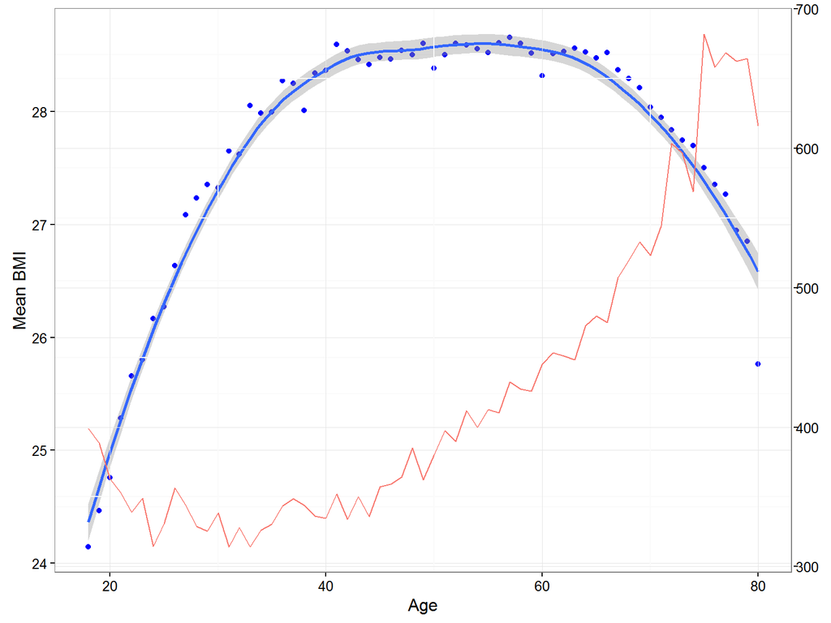

```r
    grid.newpage()

    p1 <- ggplot(mean.bmi, aes(x = X_age80, y = mean)) +
    geom_point(col = 'blue') +
    ylab('Mean BMI') + xlab("Age") +
    geom_smooth() + theme_bw()

    p2 <- ggplot(mean.exercise, aes(x = X_age80, y = mean)) +
    geom_line(aes(y = mean.exercise$mean, colour = "red")) +
    ylab('Mean fruit and vegi consumption') +
    theme_bw() %+replace%
    theme(panel.background = element_rect(fill = NA), plot.margin = unit(c(2,2,2,2), 'cm'))

    overlay(p1, p2)
```